# 2. Principal Component Analysis (PCA)

## *Principal Component Analysis (PCA)*

*Datasets that have a large number features pose a unique challenge for machine learning analysis. We know that machine learning models can be used to classify or cluster data in order to predict future events. However, high-dimensional datasets add complexity to certain machine learning models (i.e. linear models) and, as a result, models that train on datasets with a large number features are more prone to producing error due to bias.*

*Principal Component Analyis is basically a statistical procedure to convert a set of observation of possibly correlated variables into a set of values of linearly uncorrelated variables.*

*Each of the principal components is chosen in such a way so that it would describe most of the still available variance and all these principal components are orthogonal to each other. In all principal components first principal component has maximum variance.*

*Uses of PCA:*

- *It is used to find inter-relation between variables in the data.*
- *It is used to interpret and visualize data.*
- *As number of variables are decreasing it makes further analysis simpler.*
- *It’s often used to visualize genetic distance and relatedness between populations.*

*Objectives of PCA:*

*It is basically a non-dependent procedure in which it reduces attribute space from a large number of variables to a smaller number of factors.*

*PCA is basically a dimension reduction process but there is no guarantee that the dimension is interpretable. Main task in this PCA is to select a subset of variables from a larger set, based on which original variables have the highest correlation with the principal amount.*

*PCA basically search a linear combination of variables so that we can extract maximum variance from the variables. Once this process completes it removes it and search for another linear combination which gives an explanation about the maximum proportion of remaining variance which basically leads to orthogonal factors. In this method, we analyze total variance.*

[figure not shown]

*The overall goal of PCA is to reduce the number of d dimensions (features) in a dataset by projecting it onto a k dimensional subspace where k < d. The approach used to complete PCA can be summarized as follows:*

- *Standardize the data. (Performing PCA on un-normalized variables will lead to insanely large loadings for variables with high variance. In turn, this will lead to dependence of a principal component on the variable with high variance. This is undesirable.)*
- *Use the standardized data to generate a covariance matrix (or perform Singular Vector Decomposition).*
- *Obtain eigenvectors (principal components) and eigenvalues from the covariance matrix. Each eigenvector will have a corresponding eigenvalue.*
- *Sort the eigenvalues in descending order.*
- *Select the k eigenvectors with the largest eigenvalues, where k is the number of dimensions used in the new feature space (k≤d).*
- *Construct a new matrix with the selected k eigenvectors.*

*Criteria of PCA to select components*

*There are three common criteria to select components in PCA and they are as below.*

- *Eigenvalue one criterion:* *Based on this you choose components with eigenvalues higher than 1.*
- *Amount of Explained Variance:* *Based on this, the chosen factors should explain 70 to 80% of your variance at least.*
- *Screen Plot:* *This is a graphical method in which you choose the factors until a break in the graph*

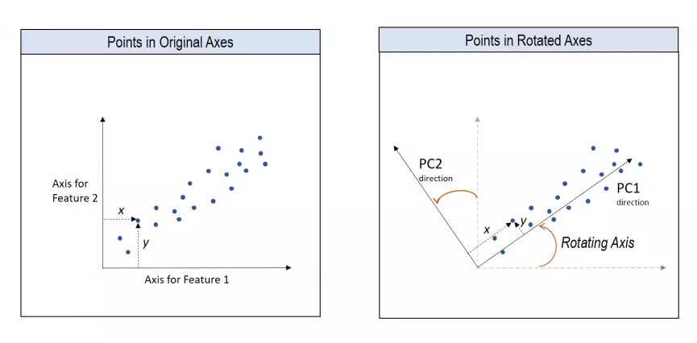

*Eigenvalue & Eigenvector*

*The below image shows one Euclidean vector having two coordinates i.e. x & y.* *Both coordinates x & y are Scalars since they are real numbers and having no direction. But “v” is not a scalar since it has a direction.*

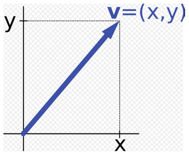

*Since we are now clear about Scalar & Vector, let’s understand Eigenvalue and Eigenvector.*

*In simple terms Eigenvalue is a Scalar and Eigenvector is a vector.*

*The difference between Eigenvector and normal vector is that Eigenvector does not change it’s direction when any linear Transformation is applied, it only changes the scalar value.*

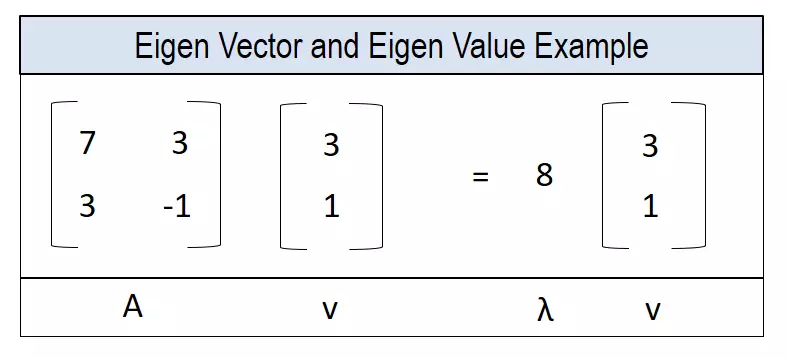

```python
# importing libraries

import pandas as pd
import numpy as np
import seaborn as sns
import matplotlib.pyplot as plt
%matplotlib inline
```

```python
from sklearn.datasets import load_breast_cancer
cancer = load_breast_cancer()
```

```python
cancer.keys()
```

```
dict_keys(['data', 'target', 'target_names', 'DESCR', 'feature_names', 'filename'])
```

```python
X = pd.DataFrame(cancer['data'],columns=cancer['feature_names'])
y = cancer['target']
X.head()
```

|  | mean radius | mean texture | mean perimeter | mean area | mean smoothness | mean compactness | mean concavity | mean concave points | mean symmetry | mean fractal dimension | ... | worst radius | worst texture | worst perimeter | worst area | worst smoothness | worst compactness | worst concavity | worst concave points | worst symmetry | worst fractal dimension |
| --- | --- | --- | --- | --- | --- | --- | --- | --- | --- | --- | --- | --- | --- | --- | --- | --- | --- | --- | --- | --- | --- |
| 0 | 17.99 | 10.38 | 122.80 | 1001.0 | 0.11840 | 0.27760 | 0.3001 | 0.14710 | 0.2419 | 0.07871 | ... | 25.38 | 17.33 | 184.60 | 2019.0 | 0.1622 | 0.6656 | 0.7119 | 0.2654 | 0.4601 | 0.11890 |
| 1 | 20.57 | 17.77 | 132.90 | 1326.0 | 0.08474 | 0.07864 | 0.0869 | 0.07017 | 0.1812 | 0.05667 | ... | 24.99 | 23.41 | 158.80 | 1956.0 | 0.1238 | 0.1866 | 0.2416 | 0.1860 | 0.2750 | 0.08902 |
| 2 | 19.69 | 21.25 | 130.00 | 1203.0 | 0.10960 | 0.15990 | 0.1974 | 0.12790 | 0.2069 | 0.05999 | ... | 23.57 | 25.53 | 152.50 | 1709.0 | 0.1444 | 0.4245 | 0.4504 | 0.2430 | 0.3613 | 0.08758 |
| 3 | 11.42 | 20.38 | 77.58 | 386.1 | 0.14250 | 0.28390 | 0.2414 | 0.10520 | 0.2597 | 0.09744 | ... | 14.91 | 26.50 | 98.87 | 567.7 | 0.2098 | 0.8663 | 0.6869 | 0.2575 | 0.6638 | 0.17300 |
| 4 | 20.29 | 14.34 | 135.10 | 1297.0 | 0.10030 | 0.13280 | 0.1980 | 0.10430 | 0.1809 | 0.05883 | ... | 22.54 | 16.67 | 152.20 | 1575.0 | 0.1374 | 0.2050 | 0.4000 | 0.1625 | 0.2364 | 0.07678 |

5 rows × 30 columns

```python
# Splitting the X and Y into the
# Training set and Testing set
from sklearn.model_selection import train_test_split

X_train, X_test, y_train, y_test = train_test_split(X, y, test_size = 0.2, random_state = 0)
```

```python
# performing preprocessing part
from sklearn.preprocessing import StandardScaler
sc = StandardScaler()

X_train = sc.fit_transform(X_train)
X_test = sc.transform(X_test)
```

### *PCA using sklearn*

```python
# Applying PCA function on training
# and testing set of X component
from sklearn.decomposition import PCA

pca = PCA(n_components = 2, random_state = 0)
pca.fit(X_train)
```

```
PCA(copy=True, iterated_power='auto', n_components=2, random_state=0,
    svd_solver='auto', tol=0.0, whiten=False)
```

```python
pca.explained_variance_ratio_
#This values show that the first principal component PC1 explains 43.43% of the variation in the original data
#while the second principal component explains 19.74% of the variation in the original data.
```

```
array([0.43430767, 0.19740115])
```

```python
pca.explained_variance_ # eigen values
```

```
array([13.05792898,  5.9350785 ])
```

```python
pca.components_
```

```
array([[ 0.22151036,  0.10450507,  0.22951189,  0.22365223,  0.13994442,
         0.24178096,  0.25999119,  0.26333456,  0.13270016,  0.05850358,
         0.20695134,  0.01284976,  0.21007605,  0.20308114,  0.0158805 ,
         0.16511631,  0.14173528,  0.18073348,  0.03361713,  0.10290725,
         0.230248  ,  0.10553057,  0.23748257,  0.22734321,  0.12954467,
         0.20947161,  0.22958661,  0.25309767,  0.11974113,  0.13016752],
       [-0.22849614, -0.05304083, -0.21198379, -0.22578551,  0.17747368,
         0.14778482,  0.0637919 , -0.03408058,  0.19056224,  0.36115407,
        -0.10875906,  0.10096927, -0.10092794, -0.15143581,  0.20845567,
         0.23829333,  0.20962214,  0.14429893,  0.1829677 ,  0.28060436,
        -0.21506139, -0.03435232, -0.19941942, -0.21424804,  0.17169435,
         0.14470833,  0.10648885, -0.00189422,  0.1442728 ,  0.27514824]])
```

```python
pca.singular_values_
```

[output not shown]

```python
X_train_pca = pca.transform(X_train)
X_test_pca = pca.transform(X_test)
```

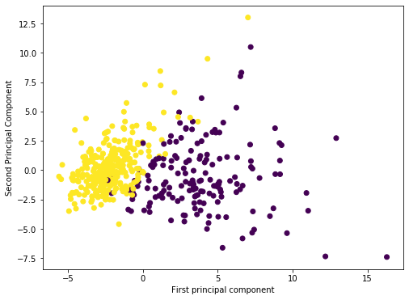

```python
plt.figure(figsize=(8,6))
plt.scatter(X_train_pca[:,0],X_train_pca[:,1],c= y_train)
plt.xlabel('First principal component')
plt.ylabel('Second Principal Component')
```

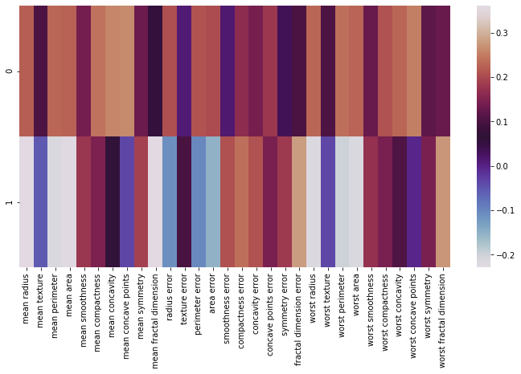

```python
map= pd.DataFrame(pca.components_,columns=cancer['feature_names'])
plt.figure(figsize=(12,6))
sns.heatmap(map,cmap='twilight')
```

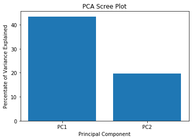

```python
percent_variance = np.round(pca.explained_variance_ratio_* 100, decimals =2)
columns = ['PC1', 'PC2']
plt.bar(x= range(1,3), height=percent_variance, tick_label=columns)
plt.ylabel('Percentate of Variance Explained')
plt.xlabel('Principal Component')
plt.title('PCA Scree Plot')
plt.show()
```

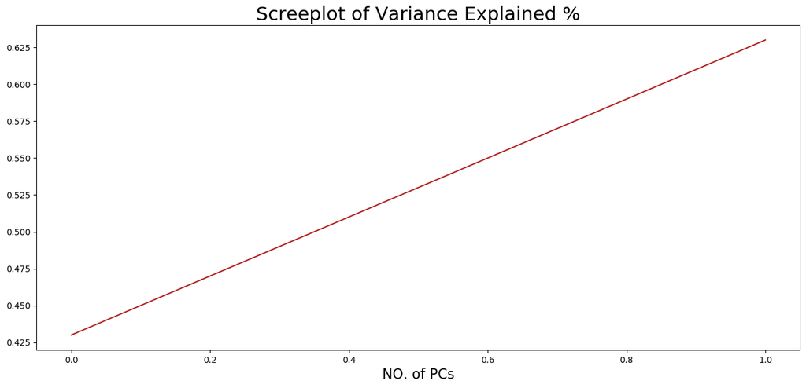

```python
### Can be used when we have lots of PC components

variance_exp_cumsum = pca.explained_variance_ratio_.cumsum().round(2)
fig, axes = plt.subplots(1,1,figsize=(16,7), dpi=100)
plt.plot(variance_exp_cumsum, color='firebrick')
plt.title('Screeplot of Variance Explained %', fontsize=22)
plt.xlabel('NO. of PCs', fontsize=16)
plt.show()
```

```python
from sklearn.ensemble import RandomForestClassifier
from sklearn.metrics import accuracy_score

def run_randomForest(X_train, X_test, y_train, y_test):
    clf = RandomForestClassifier(random_state=0, n_estimators=100, n_jobs=-1)
    clf.fit(X_train, y_train)
    y_pred = clf.predict(X_test)
    print('Accuracy: ', accuracy_score(y_test, y_pred))
```

```python
%time run_randomForest(X_train_pca, X_test_pca, y_train, y_test)
```

```
Accuracy:  0.9122807017543859
Wall time: 557 ms
```

```python
# To Select n_component with best accuracy:
for component in range(1, len(cancer['feature_names'])+1):
    print('Components: ', component)
    pca = PCA(n_components = component, random_state = 0)
    pca.fit(X_train)
    X_train_pca = pca.transform(X_train)
    X_test_pca = pca.transform(X_test)
    run_randomForest(X_train_pca, X_test_pca, y_train, y_test)
```

```
Components:  1
Accuracy:  0.8859649122807017
Components:  2
Accuracy:  0.9122807017543859
Components:  3
Accuracy:  0.9210526315789473
Components:  4
Accuracy:  0.9122807017543859
Components:  5
Accuracy:  0.956140350877193
Components:  6
Accuracy:  0.9473684210526315
Components:  7
Accuracy:  0.9473684210526315
Components:  8
Accuracy:  0.9385964912280702
Components:  9
Accuracy:  0.9385964912280702
Components:  10
Accuracy:  0.9473684210526315
Components:  11
Accuracy:  0.9298245614035088
Components:  12
Accuracy:  0.9298245614035088
Components:  13
Accuracy:  0.9473684210526315
Components:  14
Accuracy:  0.9210526315789473
Components:  15
Accuracy:  0.9298245614035088
Components:  16
Accuracy:  0.9385964912280702
Components:  17
Accuracy:  0.9210526315789473
Components:  18
Accuracy:  0.9298245614035088
Components:  19
Accuracy:  0.9035087719298246
Components:  20
Accuracy:  0.9210526315789473
Components:  21
Accuracy:  0.9298245614035088
Components:  22
Accuracy:  0.9122807017543859
Components:  23
Accuracy:  0.9210526315789473
Components:  24
Accuracy:  0.9210526315789473
Components:  25
Accuracy:  0.9298245614035088
Components:  26
Accuracy:  0.9298245614035088
Components:  27
Accuracy:  0.9210526315789473
Components:  28
Accuracy:  0.9210526315789473
Components:  29
Accuracy:  0.9122807017543859
Components:  30
Accuracy:  0.9298245614035088
```

### *PCA Vs. LDA*

*Both PCA and LDA are linear transformation techniques. However, PCA is an unsupervised while LDA is a supervised dimensionality reduction technique.*

*PCA yields the directions (principal components) that maximize the variance of the data, whereas LDA also aims to find the directions that maximize the separation (or discrimination) between different classes, which can be useful in pattern classification problem (PCA “ignores” class labels).*

*In other words, PCA projects the entire dataset onto a different feature (sub)space, and LDA tries to determine a suitable feature (sub)space in order to distinguish between patterns that belong to different classes.*

*References and other links:*

*https://medium.com/@sarayupgouda/pca-principal-component-analysis-in-python-f9836c25acb9*

*https://www.youtube.com/watch?v=FgakZw6K1QQ*

*https://www.machinelearningplus.com/machine-learning/principal-components-analysis-pca-better-explained/*

_Manual PCA: http://sebastianraschka.com/Articles/2015_pca_in_3_steps.html#pca-vs-lda_

## *Kernel PCA*

*The “classic” PCA approach described above is a linear projection technique that works well if the data is linearly separable. However, in the case of linearly inseparable data, a nonlinear technique is required if the task is to reduce the dimensionality of a dataset.*

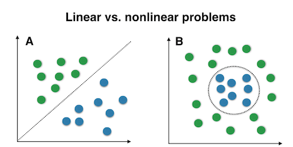

*Kernel functions and the kernel trick*

*The basic idea to deal with linearly inseparable data is to project it onto a higher dimensional space where it becomes linearly separable. Let us call this nonlinear mapping function ϕ so that the mapping of a sample x can be written as x→ϕ(x), which is called “kernel function.”*

$$κ(xi,xj)=ϕ(xi)ϕ(xj)T$$

*In other words, the function ϕ maps the original d-dimensional features into a larger, k-dimensional feature space by creating nononlinear combinations of the original features.*

*Kernel Types : Linear, Poly, RBF, Sigmoid, Cosine*

### *Half Moon Data Example*

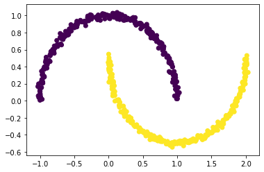

```python
import matplotlib.pyplot as plt
from sklearn.datasets import make_moons

X, y = make_moons(n_samples = 500, noise = 0.02, random_state = 417)

plt.scatter(X[:, 0], X[:, 1], c = y)
plt.show()
```

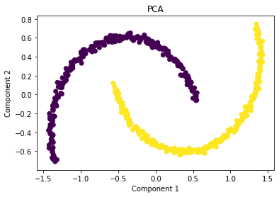

```python
### NORMAL PCA

from sklearn.decomposition import PCA
pca = PCA(n_components = 2)
X_pca = pca.fit_transform(X)

plt.title("PCA")
plt.scatter(X_pca[:, 0], X_pca[:, 1], c = y)
plt.xlabel("Component 1")
plt.ylabel("Component 2")
plt.show()
```

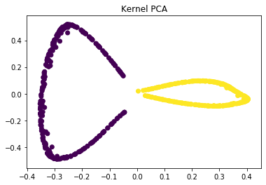

```python
### KERNEL PCA

from sklearn.decomposition import KernelPCA
kpca = KernelPCA(kernel ='rbf', gamma = 15)
X_kpca = kpca.fit_transform(X)

plt.title("Kernel PCA")
plt.scatter(X_kpca[:, 0], X_kpca[:, 1], c = y)
plt.show()
```

### *Concentric Circles Examples*

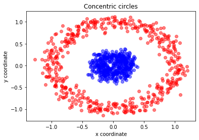

```python
from sklearn.datasets import make_circles

X, y = make_circles(n_samples=1000, random_state=123, noise=0.1, factor=0.2)

plt.figure(figsize=(6,4))

plt.scatter(X[y==0, 0], X[y==0, 1], color='red', alpha=0.5)
plt.scatter(X[y==1, 0], X[y==1, 1], color='blue', alpha=0.5)
plt.title('Concentric circles')
plt.ylabel('y coordinate')
plt.xlabel('x coordinate')
plt.show()
```

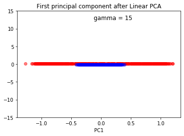

```python
import numpy as np
scikit_pca = PCA(n_components=2)
X_spca = scikit_pca.fit_transform(X)

plt.scatter(X[y==0, 0], np.zeros((500,1))+0.1, color='red', alpha=0.5)
plt.scatter(X[y==1, 0], np.zeros((500,1))-0.1, color='blue', alpha=0.5)
plt.ylim([-15,15])
plt.text(-0.125, 12.5, 'gamma = 15', fontsize=12)
plt.title('First principal component after Linear PCA')
plt.xlabel('PC1')
plt.show()
```

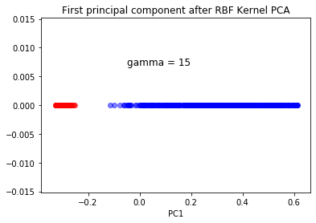

```python
kpca = KernelPCA(kernel ='rbf', gamma = 15)
X_pc = kpca.fit_transform(X)

plt.scatter(X_pc[y==0, 0], np.zeros((500,1)), color='red', alpha=0.5)
plt.scatter(X_pc[y==1, 0], np.zeros((500,1)), color='blue', alpha=0.5)
plt.text(-0.05, 0.007, 'gamma = 15', fontsize=12)
plt.title('First principal component after RBF Kernel PCA')
plt.xlabel('PC1')
plt.show()
```